# Assignment#4-4.5.2

2020-04-06

This is the fourth assignment about prediction. Chapter 4, Exercise 4.5.2: ELECTION AND CONDITIONAL CASH TRANSFER PROGRAM IN MEXICO.

## Question 1

Estimate the impact of the CCT program on turnout and support for the incumbent party (PRI) by comparing the average electoral outcomes in the “treated” (early Progresa) precincts versus the ones observed in the “control” (late Progresa) precincts. Next, estimate these effects by regressing the outcome variable on the treatment variable. Interpret and compare the estimates under these approaches. Here, following the original analysis, use the turnout and support rates as shares of the eligible voting population (t2000 and pri2000s,respectively).Do the results support the hypothesis? Provide a brief interpretation.

### Answer 1

```r
setwd("C:/HISTPOL802/function")
CCT <- read.csv("C:/HISTPOL802/function/qss-master/PREDICTION/progresa.csv")
names(CCT)
```

```
##  [1] "treatment"  "pri2000s"   "pri2000v"   "t2000"      "t2000r"
##  [6] "pri1994"    "pan1994"    "prd1994"    "pri1994s"   "pri1994v"
## [11] "pan1994s"   "pan1994v"   "prd1994s"   "prd1994v"   "t1994"
## [16] "t1994r"     "votos1994"  "avgpoverty" "pobtot1994" "villages"
```

```r
tapply(CCT$t2000, CCT$treatment, mean)
```

```
##        0        1
## 63.81483 68.08451
```

```r
tapply(CCT$pri2000s, CCT$treatment, mean)
```

```
##        0        1
## 34.48895 38.11145
```

```r
m1 <- lm(t2000~treatment, data = CCT)
summary(m1)
```

```
##
## Call:
## lm(formula = t2000 ~ treatment, data = CCT)
##
## Residuals:
##     Min      1Q  Median      3Q     Max
## -66.300 -11.700  -1.841   7.778 303.344
##
## Coefficients:
##             Estimate Std. Error t value Pr(>|t|)
## (Intercept)   63.815      2.631  24.255   <2e-16 ***
## treatment      4.270      3.216   1.327    0.185
## ---
## Signif. codes:  0 '***' 0.001 '**' 0.01 '*' 0.05 '.' 0.1 ' ' 1
##
## Residual standard error: 30.91 on 415 degrees of freedom
## Multiple R-squared:  0.004228,   Adjusted R-squared:  0.001829
## F-statistic: 1.762 on 1 and 415 DF,  p-value: 0.1851
```

```r
m2 <- lm(pri2000s~treatment, data = CCT)
summary(m2)
```

```
##
## Call:
## lm(formula = pri2000s ~ treatment, data = CCT)
##
## Residuals:
##     Min      1Q  Median      3Q     Max
## -37.370 -11.332  -1.673   9.200 104.111
##
## Coefficients:
##             Estimate Std. Error t value Pr(>|t|)
## (Intercept)   34.489      1.554  22.196   <2e-16 ***
## treatment      3.622      1.900   1.907   0.0572 .
## ---
## Signif. codes:  0 '***' 0.001 '**' 0.01 '*' 0.05 '.' 0.1 ' ' 1
##
## Residual standard error: 18.25 on 415 degrees of freedom
## Multiple R-squared:  0.008686,   Adjusted R-squared:  0.006298
## F-statistic: 3.636 on 1 and 415 DF,  p-value: 0.05722
```

The average electoral outcomes on turnout and support for the incumbent party (PRI) show that there is an increase in the “treated” precinct. The linear regression of turnout and PRI votes both present an increasing tendency, supporting the hypothesis that having CCT program longer would mobilize voters, lead to an increase in turnout and support for the incumbent party. But the problem is that the model I use seems not proper or good enough.

## Question 2

In the original analysis, the author ﬁts a linear regression model that includes,as predictors, a set of pretreatment covariates as well as the treatment variable. Here, we ﬁt a similar model for each outcome that includes the average poverty level in a precinct (avgpoverty), the total precinct population in 1994 (pobtot1994), the total number of voters who turned out in the previous election (votos1994), and the total number of votes cast for each of the three main competing parties in the previous election (pri1994 forPRI, pan1994 for Partido Acción Nacional or PAN, and prd1994 for Partido de la Revolución Democrática or PRD). Use the same outcome variables as in the original analysis, which are based on the shares of the voting age population. According to this model, what are the estimated average effects of the program’s availability on turnout and support for the incumbent party? Are these results different from those you obtained in the previous question?

### Answer 2

```r
m1.turnout<-lm(t2000 ~ treatment + avgpoverty + pobtot1994 + votos1994 + pri1994 + pan1994 + prd1994, data = CCT)
summary(m1.turnout)
```

```
##
## Call:
## lm(formula = t2000 ~ treatment + avgpoverty + pobtot1994 + votos1994 +
##     pri1994 + pan1994 + prd1994, data = CCT)
##
## Residuals:
##     Min      1Q  Median      3Q     Max
## -50.173 -11.924  -2.938   6.972 302.183
##
## Coefficients:
##               Estimate Std. Error t value Pr(>|t|)
## (Intercept) 64.0117350 17.3115236   3.698 0.000247 ***
## treatment    4.5494445  3.1346655   1.451 0.147454
## avgpoverty   0.3102553  3.5223779   0.088 0.929855
## pobtot1994  -0.0012128  0.0002316  -5.236 2.63e-07 ***
## votos1994   -0.0261518  0.0354456  -0.738 0.461059
## pri1994      0.0360555  0.0409173   0.881 0.378739
## pan1994      0.0265376  0.0595018   0.446 0.655836
## prd1994      0.0175753  0.0426669   0.412 0.680615
## ---
## Signif. codes:  0 '***' 0.001 '**' 0.01 '*' 0.05 '.' 0.1 ' ' 1
##
## Residual standard error: 29.95 on 409 degrees of freedom
## Multiple R-squared:  0.0785, Adjusted R-squared:  0.06273
## F-statistic: 4.978 on 7 and 409 DF,  p-value: 2.01e-05
```

```r
m2.pri<-lm(pri2000s ~ treatment + avgpoverty + pobtot1994 + votos1994 + pri1994 + pan1994 + prd1994, data = CCT)
summary(m2.pri)
```

```
##
## Call:
## lm(formula = pri2000s ~ treatment + avgpoverty + pobtot1994 +
##     votos1994 + pri1994 + pan1994 + prd1994, data = CCT)
##
## Residuals:
##     Min      1Q  Median      3Q     Max
## -32.297  -9.854  -1.322   6.468  94.918
##
## Coefficients:
##               Estimate Std. Error t value Pr(>|t|)
## (Intercept) 37.9500862  9.4239516   4.027 6.73e-05 ***
## treatment    2.9277395  1.7064319   1.716  0.08697 .
## avgpoverty   0.5329801  1.9174926   0.278  0.78119
## pobtot1994  -0.0004996  0.0001261  -3.962 8.77e-05 ***
## votos1994   -0.0417278  0.0192957  -2.163  0.03116 *
## pri1994      0.0624589  0.0222744   2.804  0.00529 **
## pan1994     -0.0487349  0.0323913  -1.505  0.13321
## prd1994     -0.0287363  0.0232268  -1.237  0.21672
## ---
## Signif. codes:  0 '***' 0.001 '**' 0.01 '*' 0.05 '.' 0.1 ' ' 1
##
## Residual standard error: 16.3 on 409 degrees of freedom
## Multiple R-squared:  0.2206, Adjusted R-squared:  0.2073
## F-statistic: 16.54 on 7 and 409 DF,  p-value: < 2.2e-16
```

## Question 3

Next, we consider an alternative, and more natural, model speciﬁcation. We will use the original outcome variables as in the previous question. However, our model should include the previous election outcome variables measured as shares of the voting age population (as done for the outcome variables t1994, pri1994s, pan1994s, andprd1994s) instead of those measured in counts. In addition, we apply the natural logarithmic transformation to the precinct population variable when including it as a predictor. As in the original model, our model includes the average poverty index as an additional predictor. Are the results based on these new model speciﬁcations different from those we obtained in the previous question? If the results are different, which model ﬁts the data better?

### Answer 3

```r
m1.ratio <- lm(t2000 ~ treatment + avgpoverty + log(pobtot1994) + t1994 + pri1994s + pan1994s + prd1994s, data = CCT)
summary(m1.ratio)
```

```
##
## Call:
## lm(formula = t2000 ~ treatment + avgpoverty + log(pobtot1994) +
##     t1994 + pri1994s + pan1994s + prd1994s, data = CCT)
##
## Residuals:
##      Min       1Q   Median       3Q      Max
## -119.044   -7.248   -1.180    5.579  176.967
##
## Coefficients:
##                 Estimate Std. Error t value Pr(>|t|)
## (Intercept)      19.7984    14.4292   1.372  0.17078
## treatment        -0.1530     1.8182  -0.084  0.93299
## avgpoverty        2.8621     1.8954   1.510  0.13180
## log(pobtot1994)  -3.2471     1.1678  -2.780  0.00568 **
## t1994             0.6605     0.1292   5.112 4.91e-07 ***
## pri1994s          0.1943     0.1371   1.417  0.15720
## pan1994s          0.6374     0.2121   3.005  0.00282 **
## prd1994s          0.3065     0.1471   2.084  0.03780 *
## ---
## Signif. codes:  0 '***' 0.001 '**' 0.01 '*' 0.05 '.' 0.1 ' ' 1
##
## Residual standard error: 17.31 on 409 degrees of freedom
## Multiple R-squared:  0.6921, Adjusted R-squared:  0.6868
## F-statistic: 131.3 on 7 and 409 DF,  p-value: < 2.2e-16
```

```r
m2.ratio <- lm(pri2000s ~ treatment + avgpoverty + log(pobtot1994) + t1994 + pri1994s + pan1994s + prd1994s, data = CCT)
summary(m2.ratio)
```

```
##
## Call:
## lm(formula = pri2000s ~ treatment + avgpoverty + log(pobtot1994) +
##     t1994 + pri1994s + pan1994s + prd1994s, data = CCT)
##
## Residuals:
##     Min      1Q  Median      3Q     Max
## -61.330  -7.237  -0.430   6.116  55.869
##
## Coefficients:
##                 Estimate Std. Error t value Pr(>|t|)
## (Intercept)     35.85174    9.98288   3.591 0.000369 ***
## treatment        0.23547    1.25790   0.187 0.851602
## avgpoverty       2.47163    1.31133   1.885 0.060161 .
## log(pobtot1994) -4.62934    0.80798  -5.730 1.96e-08 ***
## t1994            0.03257    0.08939   0.364 0.715792
## pri1994s         0.51047    0.09488   5.380 1.26e-07 ***
## pan1994s        -0.18384    0.14676  -1.253 0.211052
## prd1994s        -0.05293    0.10175  -0.520 0.603192
## ---
## Signif. codes:  0 '***' 0.001 '**' 0.01 '*' 0.05 '.' 0.1 ' ' 1
##
## Residual standard error: 11.98 on 409 degrees of freedom
## Multiple R-squared:  0.5794, Adjusted R-squared:  0.5722
## F-statistic: 80.48 on 7 and 409 DF,  p-value: < 2.2e-16
```

```r
summary(m1.turnout)$adj.r.squared
```

```
## [1] 0.06273301
```

```r
summary(m1.ratio)$adj.r.squared
```

```
## [1] 0.6868331
```

```r
summary(m2.pri)$adj.r.squared
```

```
## [1] 0.2072516
```

```r
summary(m2.ratio)$adj.r.squared
```

```
## [1] 0.5721621
```

The result is different from earlier results I get. The new model with t2000 has negative slope, which is different with earlier one. The new model of supporting the incumbent party has lower slope than the earlier one. The adjusted R-squared of those results increase, representing that the new calculated variables improve the model fit more than expected. Hence, this model fits the data better.

## Question 4

We examine the balance of some pretreatment variables used in the previous analyses. Using box plots, compare the distributions of the precinct population (on the original scale), average poverty index, previous turnout rate (as a share of the voting age population), and previous PRI support rate (as a share of the voting age population) between the treatment and control groups. Comment on the patterns you observe.

### Answer 4

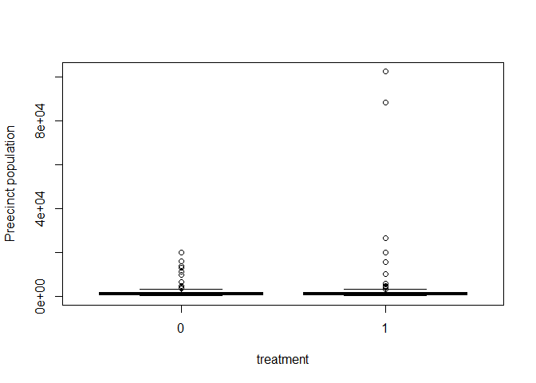

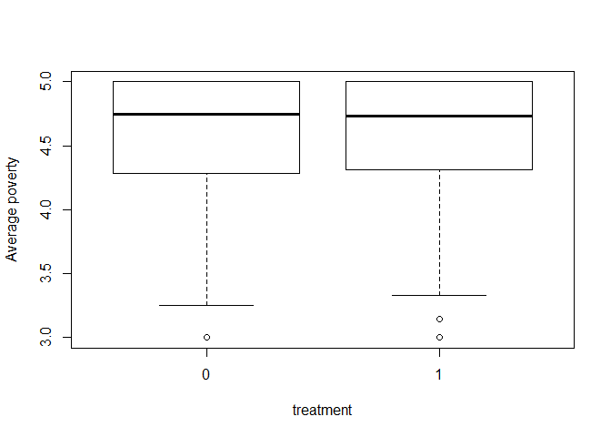

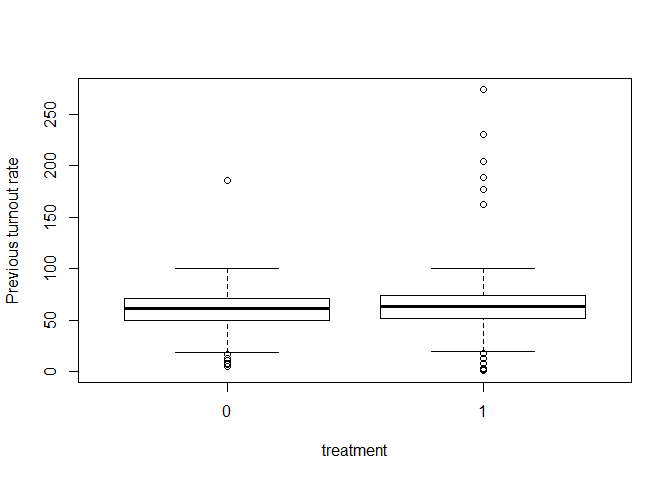

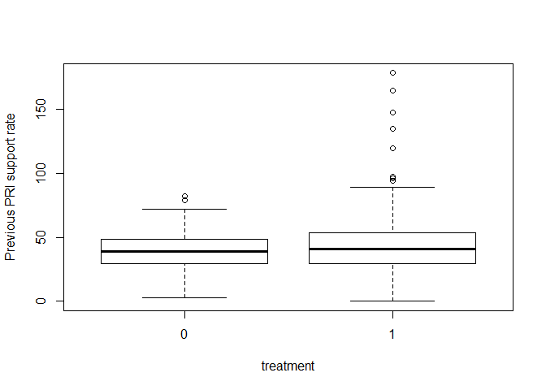

```r
boxplot(pobtot1994~treatment, data = CCT, ylab = "Preecinct population")
boxplot(avgpoverty~treatment, data = CCT, ylab = "Average poverty")
boxplot(t1994~treatment, data = CCT, ylab = "Previous turnout rate")
boxplot(pri1994s~treatment, data = CCT, ylab = "Previous PRI support rate")
```

Overall, there was little difference between the treatment groups and the control groups. But the treatment groups are more dispersed. There are more observations that fall outside the 1.5 IQR of the Lower and upper quartile. The medains of treatment group in turnout and PRI support are relativley higher than the control group. And the poverty of treatment group is lower than the control group.

## Question 5

We next use the ofﬁcial turnout rate t2000r (as a share of the registered voters) as the outcome variable rather than the turnout rate used in the original analysis (as a share of the voting age population). Similarly, we use the ofﬁcial PRI’s voteshare pri2000v (as a share of all votes cast) rather than the PRI’s support rate (as a share of the voting age population). Compute the average treatment effect of the CCT program using a linear regression with the average poverty index, the log-transformed precinct population, and the previous ofﬁcial election outcome variables (t1994r for the previous turnout; pri1994v, pan1994v, and prd1994v for the previous PRI, PAN, and PRD vote shares). Brieﬂy interpret the results.

### Answer 5

```r
m1.official <- lm(t2000r ~ treatment + avgpoverty + log(pobtot1994) + t1994r + pri1994v + pan1994v + prd1994v, data = CCT)
summary(m1.official)
```

```
##
## Call:
## lm(formula = t2000r ~ treatment + avgpoverty + log(pobtot1994) +
##     t1994r + pri1994v + pan1994v + prd1994v, data = CCT)
##
## Residuals:
##     Min      1Q  Median      3Q     Max
## -38.041  -4.555   0.029   5.010  29.069
##
## Coefficients:
##                 Estimate Std. Error t value Pr(>|t|)
## (Intercept)     33.47237    8.85553   3.780 0.000180 ***
## treatment       -1.08094    0.81683  -1.323 0.186465
## avgpoverty      -0.27734    0.88768  -0.312 0.754874
## log(pobtot1994) -0.27878    0.47487  -0.587 0.557487
## t1994r           0.22238    0.03102   7.168 3.59e-12 ***
## pri1994v         0.12473    0.05489   2.272 0.023586 *
## pan1994v         0.27356    0.07257   3.770 0.000188 ***
## prd1994v         0.11323    0.05790   1.955 0.051209 .
## ---
## Signif. codes:  0 '***' 0.001 '**' 0.01 '*' 0.05 '.' 0.1 ' ' 1
##
## Residual standard error: 7.795 on 408 degrees of freedom
##   (1 observation deleted due to missingness)
## Multiple R-squared:  0.1809, Adjusted R-squared:  0.1669
## F-statistic: 12.87 on 7 and 408 DF,  p-value: 5.603e-15
```

```r
m2.official <- lm(pri2000v ~ treatment + avgpoverty + log(pobtot1994) + t1994r + pri1994v + pan1994v + prd1994v, data = CCT)
summary(m2.official)
```

```
##
## Call:
## lm(formula = pri2000v ~ treatment + avgpoverty + log(pobtot1994) +
##     t1994r + pri1994v + pan1994v + prd1994v, data = CCT)
##
## Residuals:
##     Min      1Q  Median      3Q     Max
## -37.876  -7.686   1.072   7.461  34.758
##
## Coefficients:
##                 Estimate Std. Error t value Pr(>|t|)
## (Intercept)     50.22721   14.43904   3.479 0.000558 ***
## treatment        0.80172    1.33185   0.602 0.547536
## avgpoverty       3.19082    1.44737   2.205 0.028042 *
## log(pobtot1994) -2.59489    0.77428  -3.351 0.000879 ***
## t1994r          -0.08612    0.05058  -1.703 0.089421 .
## pri1994v         0.35738    0.08950   3.993 7.73e-05 ***
## pan1994v        -0.48863    0.11832  -4.130 4.41e-05 ***
## prd1994v        -0.24158    0.09441  -2.559 0.010862 *
## ---
## Signif. codes:  0 '***' 0.001 '**' 0.01 '*' 0.05 '.' 0.1 ' ' 1
##
## Residual standard error: 12.71 on 408 degrees of freedom
##   (1 observation deleted due to missingness)
## Multiple R-squared:  0.4836, Adjusted R-squared:  0.4747
## F-statistic: 54.58 on 7 and 408 DF,  p-value: < 2.2e-16
```

## Question 6

So far we have focused on estimating the average treatment effects of the CCT program. However, these effects may vary from one precinct to another. One important dimension to consider is poverty. We may hypothesize that since individuals in precincts with higher levels of poverty are more receptive to cash transfers, they are more likely to turn out in the election and support the incumbent party when receiving the CCT program. Assess this possibility by examining how the average treatment effect of the policy varies by different levels of poverty for precincts. To do so, ﬁt a linear regression with the following predictors: the treatment variable, the log-transformed precinct population, the average poverty index and its square, the interaction between the treatment and the poverty index, and the interaction between the treatment and the squared poverty index. Estimate the average effects for unique observed values and plot them as a function of the average poverty level. Comment on the resulting plot.

### Answer 6

```r
m1.poverty <- lm(t2000r ~ log(pobtot1994) + treatment * avgpoverty + treatment * I(avgpoverty^2) , data = CCT)
summary(m1.poverty)
```

```
##
## Call:
## lm(formula = t2000r ~ log(pobtot1994) + treatment * avgpoverty +
##     treatment * I(avgpoverty^2), data = CCT)
##
## Residuals:
##     Min      1Q  Median      3Q     Max
## -29.845  -5.112  -0.131   5.660  31.132
##
## Coefficients:
##                           Estimate Std. Error t value Pr(>|t|)
## (Intercept)                32.7086    56.4851   0.579    0.563
## log(pobtot1994)            -0.8298     0.5048  -1.644    0.101
## treatment                  33.1492    64.2260   0.516    0.606
## avgpoverty                 19.5035    25.9229   0.752    0.452
## I(avgpoverty^2)            -2.7373     2.9727  -0.921    0.358
## treatment:avgpoverty      -18.1425    29.9031  -0.607    0.544
## treatment:I(avgpoverty^2)   2.3029     3.4439   0.669    0.504
##
## Residual standard error: 8.436 on 410 degrees of freedom
## Multiple R-squared:  0.03693,    Adjusted R-squared:  0.02283
## F-statistic:  2.62 on 6 and 410 DF,  p-value: 0.0167
```

```r
yT.hat <- predict(m1.poverty, CCT = data.fram(avgpoverty = 2:6, treatment = 1))
yC.hat <- predict(m1.poverty, CCT = data.fram(avgpoverty = 2:6, treatment = 0))
library(interactions)
```

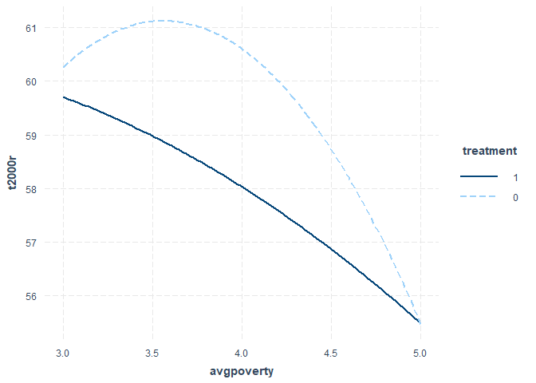

```r
interact_plot(m1.poverty, pred = avgpoverty, modx = treatment, data = CCT)
```

Here is another try.

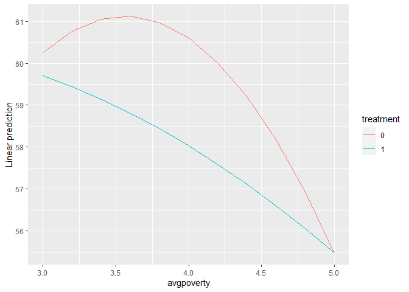

```r
library(emmeans)
mylist <- list(avgpoverty=seq(3,5,by=0.2), treatment = c(0,1))
emmip(m1.poverty,treatment~avgpoverty,at=mylist)
```

The plot is using the average poverty as the Xray, the treatment group and control group are in the plot. It shows that for the group received earlier CCT program, the lower level of poverty, people are more willing to vote. But for the group received later CCT program, people enjoyed a curve: under the level of 3.6, the poorer people are, they are more mobilized to vote; above the level of 3.6, the higher level of poverty, they are more reluctent to vote.